# Test of models

Ye Dam Yi

4/8/2021

### Test of the models

#### Libraries

```r
require(lavaan)
library(tidyverse)
library(haven)
library(QuantPsyc)
```

#### Load data

```r
risk_excluded <- read_sav("data/risk_excluded.sav")
glimpse(risk_excluded)
```

```
## Rows: 569
## Columns: 22
## $ consent     <dbl+lbl> 1, 1, 1, 1, 1, 1, 1, 1, 1, 1, 1, 1, 1, 1, 1, 1, 1, 1, …
## $ time        <dbl> 244, 180, 283, 357, 392, 218, 391, 265, 278, 203, 230, 286…
## $ age         <dbl> 38, 43, 35, 54, 44, 40, 41, 42, 30, 58, 36, 37, 26, 37, 27…
## $ gender      <dbl+lbl> 2, 1, 1, 2, 1, 1, 1, 2, 1, 2, 1, 2, 2, 2, 2, 1, 1, 1, …
## $ gendcond    <chr> "femsur", "malpred", "malself", "femself", "malsur", "mals…
## $ condition   <dbl+lbl> 2, 3, 1, 1, 2, 2, 1, 3, 3, 1, 2, 3, 1, 2, 2, 1, 3, 3, …
## $ friend1     <chr> "rachel", "malathi", "ROBERT", "Clare", "Sean", "Shaun", "…
## $ friend2     <chr> "vane", "yuvarani", "MICHAEL", "Mary", "William", "Robert"…
## $ risklevel   <dbl+lbl> 5, 5, 4, 0, 6, 0, 1, 4, 4, 3, 2, 6, 2, 5, 4, 1, 4, 5, …
## $ pos         <dbl+lbl> 4, 4, 2, 2, 4, 3, 3, 4, 4, 2, 4, 3, 3, 4, 3, 3, 2, 4, …
## $ neg         <dbl+lbl> 0, 2, 1, 2, 4, 3, 3, 3, 3, 0, 3, 3, 4, 4, 2, 1, 2, 1, …
## $ alert       <dbl+lbl> 3, 2, 3, 3, 4, 3, 2, 4, 4, 2, 3, 2, 3, 3, 2, 2, 3, 3, …
## $ riskyrisk   <dbl+lbl> 0, 2, 2, 2, 0, 0, 3, 1, 0, 0, 0, 3, 1, 3, 1, 1, 2, 0, …
## $ riskavrisk  <dbl+lbl> 0, 3, 3, 0, 3, 0, 1, 0, 0, 4, 1, 4, 0, 4, 1, 1, 1, 0, …
## $ rel_self    <dbl+lbl> 1, 1, 1, 2, 2, 1, 1, 2, 1, 1, 1, 1, 1, 1, 1, 2, 1, 1, …
## $ rel_friend1 <dbl+lbl> 2, 1, 1, 2, 2, 2, 1, 2, 1, 1, 2, 1, 2, 1, 1, 2, 2, 1, …
## $ rel_friend2 <dbl+lbl> 2, 1, 1, 2, 2, 2, 1, 2, 1, 1, 2, 1, 1, 1, 1, 2, 2, 2, …
## $ attention1  <dbl+lbl> 7, 7, 7, 7, 7, 7, 7, 7, 7, 7, 7, 7, 7, 7, 7, 7, 7, 7, …
## $ attention2  <dbl+lbl> 3, 3, 3, 3, 3, 3, 3, 3, 3, 3, 3, 3, 3, 3, 3, 3, 3, 3, …
## $ code        <chr> "Melissa38", "m1234567", "G568D498R5", "Josiejo6", "1956ab…
## $ id          <dbl> 1, 2, 3, 4, 5, 6, 7, 8, 9, 10, 11, 12, 13, 14, 15, 16, 17,…
## $ code_mturk  <chr> "m1234567", "Josiejo6", "below123", "1234567890", "R9600pD…
```

```r
# convert type
risk_excluded <- risk_excluded %>%
  mutate(gender = as_factor(gender),
         condition = as_factor(condition),
         rel_self = as_factor(rel_self),
         rel_friend1 = as_factor(rel_friend1),
         rel_friend2 = as_factor(rel_friend2))

# write_sav(risk_excluded, "data/risk_excluded.sav")

# check data
glimpse(risk_excluded)
```

```
## Rows: 569
## Columns: 22
## $ consent     <dbl+lbl> 1, 1, 1, 1, 1, 1, 1, 1, 1, 1, 1, 1, 1, 1, 1, 1, 1, 1, …
## $ time        <dbl> 244, 180, 283, 357, 392, 218, 391, 265, 278, 203, 230, 286…
## $ age         <dbl> 38, 43, 35, 54, 44, 40, 41, 42, 30, 58, 36, 37, 26, 37, 27…
## $ gender      <fct> Female, Male, Male, Female, Male, Male, Male, Female, Male…
## $ gendcond    <chr> "femsur", "malpred", "malself", "femself", "malsur", "mals…
## $ condition   <fct> Surrogate, Prediction, Self, Self, Surrogate, Surrogate, S…
## $ friend1     <chr> "rachel", "malathi", "ROBERT", "Clare", "Sean", "Shaun", "…
## $ friend2     <chr> "vane", "yuvarani", "MICHAEL", "Mary", "William", "Robert"…
## $ risklevel   <dbl+lbl> 5, 5, 4, 0, 6, 0, 1, 4, 4, 3, 2, 6, 2, 5, 4, 1, 4, 5, …
## $ pos         <dbl+lbl> 4, 4, 2, 2, 4, 3, 3, 4, 4, 2, 4, 3, 3, 4, 3, 3, 2, 4, …
## $ neg         <dbl+lbl> 0, 2, 1, 2, 4, 3, 3, 3, 3, 0, 3, 3, 4, 4, 2, 1, 2, 1, …
## $ alert       <dbl+lbl> 3, 2, 3, 3, 4, 3, 2, 4, 4, 2, 3, 2, 3, 3, 2, 2, 3, 3, …
## $ riskyrisk   <dbl+lbl> 0, 2, 2, 2, 0, 0, 3, 1, 0, 0, 0, 3, 1, 3, 1, 1, 2, 0, …
## $ riskavrisk  <dbl+lbl> 0, 3, 3, 0, 3, 0, 1, 0, 0, 4, 1, 4, 0, 4, 1, 1, 1, 0, …
## $ rel_self    <fct> YES, YES, YES, NO, NO, YES, YES, NO, YES, YES, YES, YES, Y…
## $ rel_friend1 <fct> NO, YES, YES, NO, NO, NO, YES, NO, YES, YES, NO, YES, NO, …
## $ rel_friend2 <fct> NO, YES, YES, NO, NO, NO, YES, NO, YES, YES, NO, YES, YES,…
## $ attention1  <dbl+lbl> 7, 7, 7, 7, 7, 7, 7, 7, 7, 7, 7, 7, 7, 7, 7, 7, 7, 7, …
## $ attention2  <dbl+lbl> 3, 3, 3, 3, 3, 3, 3, 3, 3, 3, 3, 3, 3, 3, 3, 3, 3, 3, …
## $ code        <chr> "Melissa38", "m1234567", "G568D498R5", "Josiejo6", "1956ab…
## $ id          <dbl> 1, 2, 3, 4, 5, 6, 7, 8, 9, 10, 11, 12, 13, 14, 15, 16, 17,…
## $ code_mturk  <chr> "m1234567", "Josiejo6", "below123", "1234567890", "R9600pD…
```

```r
# # reorder condition levels
# risk_excluded <- risk_excluded %>%
#   mutate(condition = fct_relevel(condition, "Self", "Surrogate", "Prediction"),
#          condition = fct_drop(condition))
```

#### Coding for lavaan

##### Approach 1 - dummy coding

```r
# recode condition into two different conditions:
# 1. self vs. surrogate decisions & 2. self decisions vs. predictions
# THe approach below didn't work with the error "x must be a `factor` object, not a logical vector." There seem to be no factor equivalent for NA
# risk_final <- risk_excluded %>%
#   mutate(recipient_sur = case_when(
#     condition == "Self" ~ condition,
#     condition == "Surrogate" ~ condition,
#     condition == "Prediction" ~ NA
#   ),
#     recipient_pred == case_when(
#       condition == "Self" ~ condition,
#       condition == "Surrogate" ~ NA,
#       condition == "Prediction" ~ condition
#     ))


# check factor levels
# levels(risk_excluded$condition)
glimpse(risk_excluded)

  # risk_final <- risk_excluded %>%
  # mutate(recipient_sur = fct_recode(condition, NULL = "Prediction"),
  #        recipient_pred = fct_recode(condition, NULL = "Surrogate"))

risk_final <- risk_excluded %>%
  mutate(condition_sur = case_when(
    condition == "Surrogate" ~ "1",
    TRUE ~ "0"),
    condition_pred = case_when(
      condition == "Prediction" ~ "1",
      TRUE ~ "0")) %>%
  mutate(condition_sur = as.numeric(condition_sur),
         condition_pred = as.numeric(condition_pred))
```

I’m not really sure about this approach because if I used the dummy-coded condition_sur or condition_pred in my analysis, the observations belonging to prediction will be included in my analysis of self vs. surrogate conditions and vice versa. So I’m going to subset datasets into two.

##### Approach 2 - subsetting datasets

```r
# subset self & surrogate
risk_sur <- risk_excluded %>%
  filter(condition == "Self" | condition == "Surrogate") %>%
  mutate(condition = fct_drop(condition)) %>%  # drop irrelevant level
  mutate(recipient_num = as.numeric(as.character(fct_recode(condition, "0" = "Self", "1" = "Surrogate"))))

# subset self & prediction
risk_pred <- risk_excluded %>%
  filter(condition == "Self" | condition == "Prediction") %>%
  mutate(condition = fct_drop(condition, only = "Surrogate")) %>%  # drop irrelevant level
  mutate(recipient_num = as.numeric(as.character(fct_recode(condition, "0" = "Self", "1" = "Prediction"))))
levels(risk_pred$condition)
```

```
## [1] "Self"       "Prediction"
```

```r
# the resulting data have three levels of condition
# drop the level that doesn't belong to each subsetted dataset

# running the SEM model with data resulted in this warning:
#   lavaan ERROR: unordered factor(s) with more than 2 levels detected as exogenous covariate(s): condition
# order data in the model fit summary didn't work
# recode variables
```

#### Check for normality

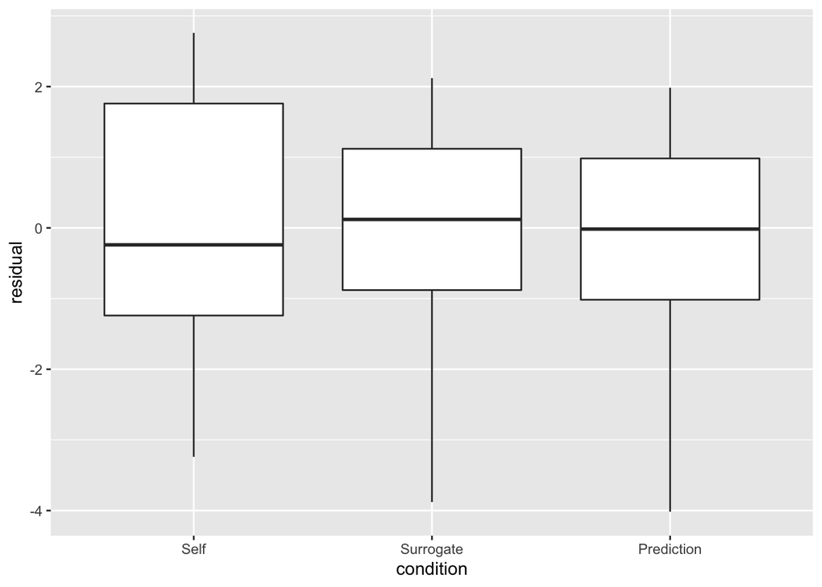

```r
# fit a model
risk_lm = lm(risklevel ~ 0 + condition, data = risk_excluded)

# create a data with two columns: condition and residuals
fits = risk_excluded %>%
    group_by(condition) %>%
    transmute(fit = mean(risklevel),
           residual = risklevel - mean(risklevel))

# look at homoscedasticity
fits %>%
  ggplot(aes(x = condition, y = residual)) +
  geom_boxplot()
```

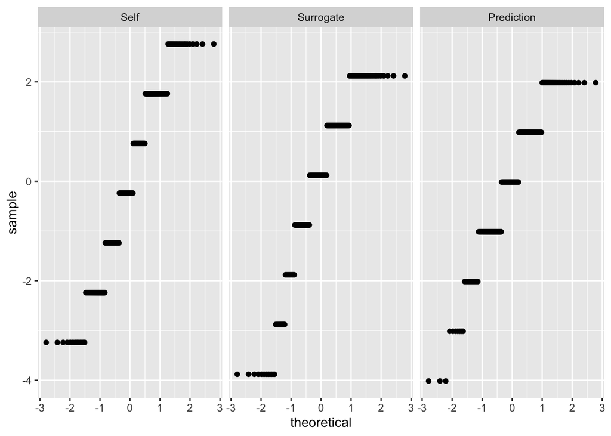

```r
# look at normality of the residuals by condition
fits %>%
  ggplot(aes(sample = residual)) +
  stat_qq() + facet_wrap(~ condition, ncol = 3)
```

```r
# get the sd of the model
sd(risk_lm$residual)
```

```
## [1] 1.640251
```

```r
round(summary(risk_lm)$sigma, 2)
```

```
## [1] 1.64
```

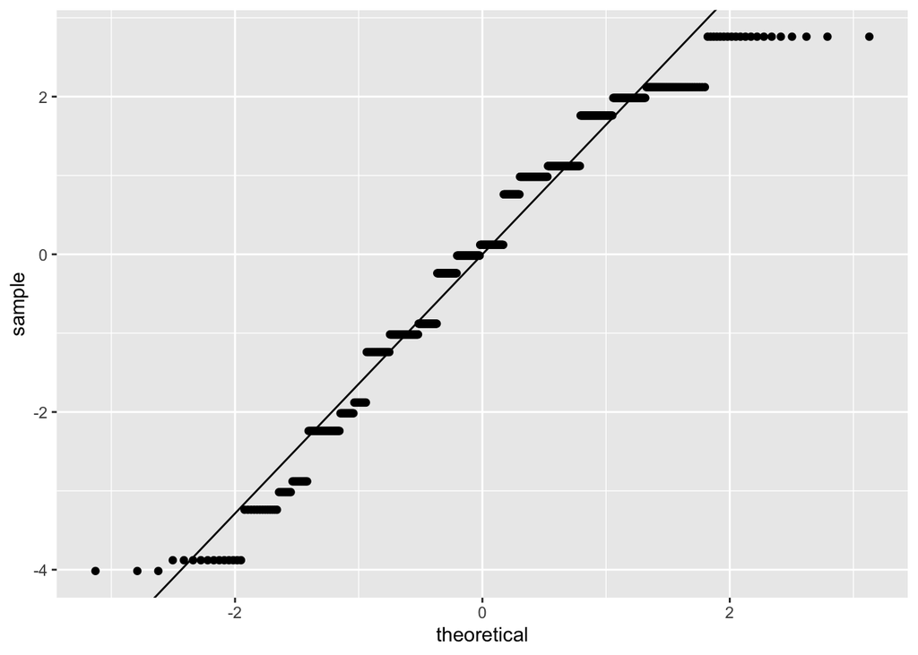

```r
# look at how the residuals compare to the fitted model of residuals
fits %>%
  ggplot(aes(sample = residual)) +
  stat_qq() + geom_abline(intercept = mean(fits$residual), slope = summary(risk_lm)$sigma)
```

#### Self vs. surrogate decisions

##### Approach 1 - Didn’t work

```r
# total effect of recipient on y not controlling for m
self_sur_mediation <- '
    # direct effect
    risklevel ~ b1 * neg + b2 * pos + b3 * alert + c * condition_sur
    # mediator
    neg ~ a1 * condition_sur
    pos ~ a2 * condition_sur
    alert ~ a3 * condition_sur
    # indirect effect (a*b)
    indirect1 := a1 * b1
    indirect2 := a2 * b2
    Indirect3 := a3 * b3
    # total effect
    total := c + (a1 * b1) + (a2 * b2) + (a3 * b3)
    # covariances
    neg ~~ pos
    pos ~~ alert
    neg ~~ alert
'
self_sur_fit <- sem(model = self_sur_mediation, data = risk_final, se = "bootstrap", bootstrap = 5000)
summary(self_sur_fit, fit.measures = TRUE, standardize = TRUE, estimates = TRUE)

mi <- modindices(self_sur_fit)
fitmeasures(self_sur_fit)
```

The nlminb command is intended for functions that have at least two continuous derivatives on all of the feasible region, including the boundary. For best results, the gradient of the objective should be supplied whenever possible. Supplying the Hessian matrix as well will sometimes, but not always, lead to a substantial decrease in the number of iterations required to reach a minimum.

##### Approach 2

```r
self_sur_mediation <- '
    # direct effect
    risklevel ~ b1 * neg + b2 * pos + b3 * alert + c * recipient_num
    # mediator
    neg ~ a1 * recipient_num
    pos ~ a2 * recipient_num
    alert ~ a3 * recipient_num
    # indirect effect (a*b)
    indirect1 := a1 * b1
    indirect2 := a2 * b2
    Indirect3 := a3 * b3
    # total effect
    total := c + (a1 * b1) + (a2 * b2) + (a3 * b3)
    # covariances
    neg ~~ pos
    pos ~~ alert
    neg ~~ alert
'
self_sur_fit <- sem(model = self_sur_mediation, data = risk_sur, se = "bootstrap", bootstrap = 5000)
summary(self_sur_fit, fit.measures = TRUE, standardize = TRUE, estimates = TRUE, rsquare = TRUE)
```

```
## lavaan 0.6-7 ended normally after 34 iterations
##
##   Estimator                                         ML
##   Optimization method                           NLMINB
##   Number of free parameters                         14
##
##   Number of observations                           383
##
## Model Test User Model:
##
##   Test statistic                                 0.000
##   Degrees of freedom                                 0
##
## Model Test Baseline Model:
##
##   Test statistic                               121.201
##   Degrees of freedom                                10
##   P-value                                        0.000
##
## User Model versus Baseline Model:
##
##   Comparative Fit Index (CFI)                    1.000
##   Tucker-Lewis Index (TLI)                       1.000
##
## Loglikelihood and Information Criteria:
##
##   Loglikelihood user model (H0)              -2248.322
##   Loglikelihood unrestricted model (H1)             NA
##
##   Akaike (AIC)                                4524.644
##   Bayesian (BIC)                              4579.917
##   Sample-size adjusted Bayesian (BIC)         4535.497
##
## Root Mean Square Error of Approximation:
##
##   RMSEA                                          0.000
##   90 Percent confidence interval - lower         0.000
##   90 Percent confidence interval - upper         0.000
##   P-value RMSEA <= 0.05                             NA
##
```

[output cut: 38 more lines]

```
##    .alert             0.691    0.062   11.168    0.000    0.691    0.998
##
## R-Square:
##                    Estimate
##     risklevel         0.179
##     neg               0.005
##     pos               0.011
##     alert             0.002
##
## Defined Parameters:
##                    Estimate  Std.Err  z-value  P(>|z|)   Std.lv  Std.all
##     indirect1        -0.012    0.018   -0.670    0.503   -0.012   -0.004
##     indirect2         0.137    0.070    1.958    0.050    0.137    0.039
##     Indirect3        -0.001    0.012   -0.094    0.925   -0.001   -0.000
##     total             0.640    0.175    3.648    0.000    0.640    0.182
```

```r
standardizedSolution(self_sur_fit)
```

```
##              lhs op                       rhs est.std    se       z pvalue
## 1      risklevel  ~                       neg  -0.047 0.051  -0.931  0.352
## 2      risklevel  ~                       pos   0.376 0.047   7.996  0.000
## 3      risklevel  ~                     alert  -0.008 0.051  -0.151  0.880
## 4      risklevel  ~             recipient_num   0.146 0.047   3.128  0.002
## 5            neg  ~             recipient_num   0.074 0.051   1.458  0.145
## 6            pos  ~             recipient_num   0.104 0.051   2.038  0.042
## 7          alert  ~             recipient_num   0.041 0.051   0.803  0.422
## 8            neg ~~                       pos  -0.110 0.051  -2.140  0.032
## 9            pos ~~                     alert   0.153 0.058   2.613  0.009
## 10           neg ~~                     alert   0.231 0.054   4.272  0.000
## 11     risklevel ~~                 risklevel   0.821 0.039  21.189  0.000
## 12           neg ~~                       neg   0.995 0.008 132.143  0.000
## 13           pos ~~                       pos   0.989 0.011  94.060  0.000
## 14         alert ~~                     alert   0.998 0.004 241.209  0.000
```

[output cut: 25 more lines]

```r
parameterEstimates(self_sur_fit, boot.ci.type = "bca.simple")
```

```
##              lhs op                       rhs     label    est    se      z
## 1      risklevel  ~                       neg        b1 -0.069 0.074 -0.931
## 2      risklevel  ~                       pos        b2  0.822 0.107  7.647
## 3      risklevel  ~                     alert        b3 -0.016 0.108 -0.151
## 4      risklevel  ~             recipient_num         c  0.516 0.165  3.130
## 5            neg  ~             recipient_num        a1  0.178 0.123  1.453
## 6            pos  ~             recipient_num        a2  0.167 0.083  2.021
## 7          alert  ~             recipient_num        a3  0.068 0.085  0.801
## 8            neg ~~                       pos           -0.106 0.051 -2.071
## 9            pos ~~                     alert            0.102 0.039  2.634
## 10           neg ~~                     alert            0.231 0.057  4.061
## 11     risklevel ~~                 risklevel            2.553 0.168 15.226
## 12           neg ~~                       neg            1.436 0.072 20.001
## 13           pos ~~                       pos            0.645 0.048 13.558
## 14         alert ~~                     alert            0.691 0.062 11.168
```

[output cut: 25 more lines]

This is a saturated model. Someone said the following about a saturated model:

Also, I see very little use of the fit indexes for path analysis. It seems incoherent to say that the relation between variables will reproduce the covariance matrix, as we can get the saturated model by including all relations.

Fit its useful for a measurement model, when you try to state that latent variables structure reproduce the covariance matrix.

I had to answer a reviewer asking me for fit measure in a model just like yours (path analysis and saturated)

#### Self decisions vs. predictions

```r
self_pred_mediation <- '
    # direct effect
    risklevel ~ b1 * neg + b2 * pos + b3 * alert + c * recipient_num
    # mediator
    neg ~ a1 * recipient_num
    pos ~ a2 * recipient_num
    alert ~ a3 * recipient_num
    # indirect effect (a*b)
    indirect1 := a1 * b1
    indirect2 := a2 * b2
    Indirect3 := a3 * b3
    # total effect
    total := c + (a1 * b1) + (a2 * b2) + (a3 * b3)
    # covariances
    neg ~~ pos
    pos ~~ alert
    neg ~~ alert
'
self_pred_fit <- sem(model = self_pred_mediation, data = risk_pred,se = "bootstrap", bootstrap = 5000)
summary(self_pred_fit, fit.measures = TRUE, standardize = TRUE, estimates = TRUE, rsquare = TRUE)
```

```
## lavaan 0.6-7 ended normally after 31 iterations
##
##   Estimator                                         ML
##   Optimization method                           NLMINB
##   Number of free parameters                         14
##
##   Number of observations                           378
##
## Model Test User Model:
##
##   Test statistic                                 0.000
##   Degrees of freedom                                 0
##
## Model Test Baseline Model:
##
##   Test statistic                               158.507
##   Degrees of freedom                                10
##   P-value                                        0.000
##
## User Model versus Baseline Model:
##
##   Comparative Fit Index (CFI)                    1.000
##   Tucker-Lewis Index (TLI)                       1.000
##
## Loglikelihood and Information Criteria:
##
##   Loglikelihood user model (H0)              -2187.119
##   Loglikelihood unrestricted model (H1)             NA
##
##   Akaike (AIC)                                4402.238
##   Bayesian (BIC)                              4457.327
##   Sample-size adjusted Bayesian (BIC)         4412.908
##
## Root Mean Square Error of Approximation:
##
##   RMSEA                                          0.000
##   90 Percent confidence interval - lower         0.000
##   90 Percent confidence interval - upper         0.000
##   P-value RMSEA <= 0.05                             NA
##
```

[output cut: 38 more lines]

```
##    .alert             0.718    0.063   11.413    0.000    0.718    1.000
##
## R-Square:
##                    Estimate
##     risklevel         0.180
##     neg               0.002
##     pos               0.006
##     alert             0.000
##
## Defined Parameters:
##                    Estimate  Std.Err  z-value  P(>|z|)   Std.lv  Std.all
##     indirect1         0.013    0.021    0.639    0.523    0.013    0.004
##     indirect2         0.082    0.059    1.397    0.162    0.082    0.025
##     Indirect3        -0.000    0.011   -0.036    0.972   -0.000   -0.000
##     total             0.777    0.167    4.651    0.000    0.777    0.234
```

```r
standardizedSolution(self_pred_fit)
```

```
##              lhs op                       rhs est.std    se        z pvalue
## 1      risklevel  ~                       neg  -0.102 0.053   -1.904  0.057
## 2      risklevel  ~                       pos   0.325 0.055    5.888  0.000
## 3      risklevel  ~                     alert  -0.021 0.057   -0.368  0.713
## 4      risklevel  ~             recipient_num   0.206 0.046    4.453  0.000
## 5            neg  ~             recipient_num  -0.039 0.052   -0.752  0.452
## 6            pos  ~             recipient_num   0.076 0.051    1.477  0.140
## 7          alert  ~             recipient_num   0.005 0.052    0.105  0.916
## 8            neg ~~                       pos  -0.178 0.052   -3.415  0.001
## 9            pos ~~                     alert   0.281 0.057    4.953  0.000
## 10           neg ~~                     alert   0.241 0.050    4.767  0.000
## 11     risklevel ~~                 risklevel   0.820 0.040   20.421  0.000
## 12           neg ~~                       neg   0.998 0.004  247.591  0.000
## 13           pos ~~                       pos   0.994 0.008  127.183  0.000
## 14         alert ~~                     alert   1.000 0.001 1770.829  0.000
```

[output cut: 25 more lines]

```r
parameterEstimates(self_pred_fit, boot.ci.type = "bca.simple")
```

```
##              lhs op                       rhs     label    est    se      z
## 1      risklevel  ~                       neg        b1 -0.143 0.076 -1.888
## 2      risklevel  ~                       pos        b2  0.645 0.112  5.737
## 3      risklevel  ~                     alert        b3 -0.041 0.111 -0.368
## 4      risklevel  ~             recipient_num         c  0.682 0.157  4.346
## 5            neg  ~             recipient_num        a1 -0.091 0.122 -0.752
## 6            pos  ~             recipient_num        a2  0.127 0.086  1.478
## 7          alert  ~             recipient_num        a3  0.009 0.088  0.105
## 8            neg ~~                       pos           -0.174 0.054 -3.205
## 9            pos ~~                     alert            0.198 0.042  4.714
## 10           neg ~~                     alert            0.239 0.056  4.298
## 11     risklevel ~~                 risklevel            2.255 0.154 14.679
## 12           neg ~~                       neg            1.374 0.069 19.833
## 13           pos ~~                       pos            0.694 0.053 13.091
## 14         alert ~~                     alert            0.718 0.063 11.413
```

[output cut: 25 more lines]

#### Moderation

##### Code variables

```r
# mean center IVs
risk_sur <- risk_sur %>%
  mutate(
        # meancenter variables
         negmc = neg - mean(neg),
         posmc = pos - mean(pos),
         alertmc = alert - mean(alert),

        # recode condition variable
         conditionrecoded = case_when(condition == "Self" ~ -1,
                         condition == "Surrogate" ~ 1),
         target = case_when(condition == "Self" ~ 0,
                         condition == "Surrogate" ~ 1),

        # create interaction terms
         negint = negmc * conditionrecoded,
         posint = posmc * conditionrecoded,
         alertint = alertmc * conditionrecoded)

write_sav(risk_sur, "data/risk_sur.sav")

risk_pred <- risk_pred %>%
   mutate(

       # meancenter variables
         negmc = neg - mean(neg),
         posmc = pos - mean(pos),
         alertmc = alert - mean(alert),

        # recode condition variable
         conditionrecoded = case_when(condition == "Self" ~ -1,
                         condition == "Prediction" ~ 1),
        target = case_when(condition == "Self" ~ 0,
                         condition == "Prediction" ~ 1),

        # create interaction terms
         negint = negmc * conditionrecoded,
         posint = posmc * conditionrecoded,
         alertint = alertmc * conditionrecoded)

write_sav(risk_pred, "data/risk_pred.sav")

# create interaction variables
```

##### Self vs. Surrogate Moderation

```r
self_sur_mod <- lm(risklevel ~ neg + pos + alert + target + negint + posint + alertint, data = risk_sur)
summary(self_sur_mod)
```

```
##
## Call:
## lm(formula = risklevel ~ neg + pos + alert + target + negint +
##     posint + alertint, data = risk_sur)
##
## Residuals:
##     Min      1Q  Median      3Q     Max
## -4.5823 -1.1132  0.2032  1.2646  3.6165
##
## Coefficients:
##             Estimate Std. Error t value Pr(>|t|)
## (Intercept)  1.04447    0.42504   2.457  0.01445 *
## neg         -0.07151    0.07231  -0.989  0.32332
## pos          0.80548    0.10626   7.580 2.73e-13 ***
## alert       -0.01005    0.10441  -0.096  0.92334
## target       0.51871    0.16628   3.119  0.00195 **
## negint       0.06786    0.07231   0.938  0.34860
## posint      -0.03091    0.10626  -0.291  0.77129
## alertint    -0.05126    0.10441  -0.491  0.62373
## ---
## Signif. codes:  0 '***' 0.001 '**' 0.01 '*' 0.05 '.' 0.1 ' ' 1
##
## Residual standard error: 1.612 on 375 degrees of freedom
## Multiple R-squared:  0.1812, Adjusted R-squared:  0.1659
## F-statistic: 11.85 on 7 and 375 DF,  p-value: 1.159e-13
```

```r
lm.beta(self_sur_mod)
```

```
##         neg         pos       alert      target      negint      posint
## -0.04873850  0.36900304 -0.00474298  0.14711062  0.04612436 -0.01408410
##    alertint
## -0.02416427
```

```r
# lavaan
self_sur_mod_lav <- '
risklevel ~ neg + pos + alert + target + negint + posint + alertint

neg ~~ pos
neg ~~ alert
neg ~~ target
pos ~~ alert
pos ~~ target
alert ~~ target

'
self_sur_mod_fit <- sem(model = self_sur_mod_lav, data = risk_sur)
summary(self_sur_mod_fit, standardized = T, rsquare = TRUE)
```

```
## lavaan 0.6-7 ended normally after 31 iterations
##
##   Estimator                                         ML
##   Optimization method                           NLMINB
##   Number of free parameters                         24
##
##   Number of observations                           383
##
## Model Test User Model:
##
##   Test statistic                                23.391
##   Degrees of freedom                                12
##   P-value (Chi-square)                           0.025
##
## Parameter Estimates:
##
##   Standard errors                             Standard
##   Information                                 Expected
##   Information saturated (h1) model          Structured
##
## Regressions:
##                    Estimate  Std.Err  z-value  P(>|z|)   Std.lv  Std.all
##   risklevel ~
##     neg              -0.072    0.071   -1.011    0.312   -0.072   -0.049
##     pos               0.805    0.104    7.755    0.000    0.805    0.370
##     alert            -0.010    0.103   -0.098    0.922   -0.010   -0.005
##     target            0.519    0.165    3.153    0.002    0.519    0.147
##     negint            0.068    0.071    0.959    0.337    0.068    0.046
##     posint           -0.031    0.104   -0.298    0.766   -0.031   -0.014
##     alertint         -0.051    0.103   -0.500    0.617   -0.051   -0.024
##
## Covariances:
##                    Estimate  Std.Err  z-value  P(>|z|)   Std.lv  Std.all
##   neg ~~
##     pos              -0.098    0.050   -1.975    0.048   -0.098   -0.101
##     alert             0.234    0.052    4.453    0.000    0.234    0.234
##     target            0.045    0.031    1.446    0.148    0.045    0.074
##   pos ~~
##     alert             0.105    0.035    3.014    0.003    0.105    0.156
##     target            0.042    0.021    2.015    0.044    0.042    0.104
##   alert ~~
##     target            0.017    0.021    0.797    0.425    0.017    0.041
##   negint ~~
##     posint           -0.106    0.049   -2.140    0.032   -0.106   -0.110
##     alertint          0.231    0.052    4.414    0.000    0.231    0.231
##   posint ~~
##     alertint          0.102    0.035    2.952    0.003    0.102    0.153
##
## Variances:
##                    Estimate  Std.Err  z-value  P(>|z|)   Std.lv  Std.all
##    .risklevel         2.545    0.184   13.838    0.000    2.545    0.823
##     neg               1.444    0.104   13.838    0.000    1.444    1.000
##     pos               0.652    0.047   13.838    0.000    0.652    1.000
##     alert             0.692    0.050   13.838    0.000    0.692    1.000
##     target            0.250    0.018   13.838    0.000    0.250    1.000
##     negint            1.436    0.104   13.838    0.000    1.436    1.000
##     posint            0.645    0.047   13.838    0.000    0.645    1.000
##     alertint          0.691    0.050   13.838    0.000    0.691    1.000
##
## R-Square:
##                    Estimate
##     risklevel         0.177
```

```r
lavInspect(self_sur_mod_fit, "cor.ov")
```

```
##           rsklvl neg    pos    alert  target negint posint alrtnt
## risklevel  1.000
## neg       -0.077  1.000
## pos        0.389 -0.101  1.000
## alert      0.048  0.234  0.156  1.000
## target     0.182  0.074  0.104  0.041  1.000
## negint     0.042  0.000  0.000  0.000  0.000  1.000
## posint    -0.023  0.000  0.000  0.000  0.000 -0.110  1.000
## alertint  -0.016  0.000  0.000  0.000  0.000  0.231  0.153  1.000
```

```r
lavTestLRT(self_sur_mod_fit, fit.measures = TRUE)
```

```
## Chi-Squared Test Statistic (unscaled)
##
##           Df    AIC    BIC  Chisq Chisq diff Df diff Pr(>Chisq)
## Saturated  0                0.000
## Model     12 8150.1 8244.9 23.391     23.391      12    0.02458 *
## ---
## Signif. codes:  0 '***' 0.001 '**' 0.01 '*' 0.05 '.' 0.1 ' ' 1
```

##### Self vs. Prediction Moderation

```r
self_pred_mod <- lm(risklevel ~ neg + pos + alert + target + negint + posint + alertint, data = risk_pred)
summary(self_pred_mod)
```

```
##
## Call:
## lm(formula = risklevel ~ neg + pos + alert + target + negint +
##     posint + alertint, data = risk_pred)
##
## Residuals:
##     Min      1Q  Median      3Q     Max
## -4.4889 -1.0460  0.0289  1.0289  3.6165
##
## Coefficients:
##              Estimate Std. Error t value Pr(>|t|)
## (Intercept)  1.706510   0.379343   4.499 9.17e-06 ***
## neg         -0.144126   0.070643  -2.040   0.0420 *
## pos          0.640408   0.102539   6.245 1.16e-09 ***
## alert       -0.016111   0.102512  -0.157   0.8752
## target       0.682576   0.155533   4.389 1.49e-05 ***
## negint      -0.004754   0.070643  -0.067   0.9464
## posint      -0.195986   0.102539  -1.911   0.0567 .
## alertint    -0.057321   0.102512  -0.559   0.5764
## ---
## Signif. codes:  0 '***' 0.001 '**' 0.01 '*' 0.05 '.' 0.1 ' ' 1
##
## Residual standard error: 1.507 on 370 degrees of freedom
## Multiple R-squared:  0.1916, Adjusted R-squared:  0.1763
## F-statistic: 12.53 on 7 and 370 DF,  p-value: 1.988e-14
```

```r
lm.beta(self_pred_mod)
```

```
##          neg          pos        alert       target       negint       posint
## -0.101989149  0.322828082 -0.008233272  0.205837777 -0.003361738 -0.098510303
##     alertint
## -0.029293179
```

```r
# lavaan
self_pred_mod_lav <- '
risklevel ~ neg + pos + alert + target + negint + posint + alertint

neg ~~ pos
neg ~~ alert
neg ~~ target
pos ~~ alert
pos ~~ target
alert ~~ target
'
self_pred_mod_fit <- sem(model = self_pred_mod_lav, data = risk_pred)
summary(self_pred_mod_fit, standardized = T, rsquare = TRUE)
```

```
## lavaan 0.6-7 ended normally after 32 iterations
##
##   Estimator                                         ML
##   Optimization method                           NLMINB
##   Number of free parameters                         24
##
##   Number of observations                           378
##
## Model Test User Model:
##
##   Test statistic                                30.269
##   Degrees of freedom                                12
##   P-value (Chi-square)                           0.003
##
## Parameter Estimates:
##
##   Standard errors                             Standard
##   Information                                 Expected
##   Information saturated (h1) model          Structured
##
## Regressions:
##                    Estimate  Std.Err  z-value  P(>|z|)   Std.lv  Std.all
##   risklevel ~
##     neg              -0.144    0.070   -2.063    0.039   -0.144   -0.102
##     pos               0.640    0.099    6.444    0.000    0.640    0.323
##     alert            -0.016    0.099   -0.163    0.871   -0.016   -0.008
##     target            0.683    0.154    4.436    0.000    0.683    0.206
##     negint           -0.005    0.070   -0.068    0.946   -0.005   -0.003
##     posint           -0.196    0.099   -1.972    0.049   -0.196   -0.099
##     alertint         -0.057    0.099   -0.578    0.563   -0.057   -0.029
##
## Covariances:
##                    Estimate  Std.Err  z-value  P(>|z|)   Std.lv  Std.all
##   neg ~~
##     pos              -0.177    0.051   -3.459    0.001   -0.177   -0.181
##     alert             0.239    0.053    4.543    0.000    0.239    0.240
##     target           -0.023    0.030   -0.757    0.449   -0.023   -0.039
##   pos ~~
##     alert             0.198    0.038    5.246    0.000    0.198    0.280
##     target            0.032    0.022    1.473    0.141    0.032    0.076
##   alert ~~
##     target            0.002    0.022    0.106    0.916    0.002    0.005
##   negint ~~
##     posint           -0.174    0.051   -3.416    0.001   -0.174   -0.178
##     alertint          0.239    0.053    4.550    0.000    0.239    0.241
##   posint ~~
##     alertint          0.198    0.038    5.253    0.000    0.198    0.281
##
## Variances:
##                    Estimate  Std.Err  z-value  P(>|z|)   Std.lv  Std.all
##    .risklevel         2.222    0.162   13.748    0.000    2.222    0.808
##     neg               1.376    0.100   13.748    0.000    1.376    1.000
##     pos               0.698    0.051   13.748    0.000    0.698    1.000
##     alert             0.718    0.052   13.748    0.000    0.718    1.000
##     target            0.250    0.018   13.748    0.000    0.250    1.000
##     negint            1.374    0.100   13.748    0.000    1.374    1.000
##     posint            0.694    0.051   13.748    0.000    0.694    1.000
##     alertint          0.718    0.052   13.748    0.000    0.718    1.000
##
## R-Square:
##                    Estimate
##     risklevel         0.192
```

```r
lavInspect(self_pred_mod_fit, "cor.ov")
```

```
##           rsklvl neg    pos    alert  target negint posint alrtnt
## risklevel  1.000
## neg       -0.170  1.000
## pos        0.355 -0.181  1.000
## alert      0.059  0.240  0.280  1.000
## target     0.234 -0.039  0.076  0.005  1.000
## negint     0.007  0.000  0.000  0.000  0.000  1.000
## posint    -0.106  0.000  0.000  0.000  0.000 -0.178  1.000
## alertint  -0.058  0.000  0.000  0.000  0.000  0.241  0.281  1.000
```

```r
lavTestLRT(self_pred_mod_fit, fit.measures = TRUE)
```

```
## Chi-Squared Test Statistic (unscaled)
##
##           Df    AIC    BIC  Chisq Chisq diff Df diff Pr(>Chisq)
## Saturated  0                0.000
## Model     12 7959.5 8053.9 30.269     30.269      12   0.002544 **
## ---
## Signif. codes:  0 '***' 0.001 '**' 0.01 '*' 0.05 '.' 0.1 ' ' 1
```